# EnrichMet Tutorial

Yonatan Ayalew Mekonnen

2025-06-05

# 1 EnrichMet

**EnrichMet** is a comprehensive tool for metabolomics pathway analysis. It performs pathway enrichment using Fisher’s exact test, computes betweenness centrality and relative betweenness centrality (RBC) for metabolites, and conducts Metabolite Set Enrichment Analysis (MetSEA). With a single function call (`enrichmet()`), the package generates a rich set of visualizations, including:

- **Pathway enrichment plot**
- **Pathway impact plot**
- **MetSEA plot**
- **RBC plot**
- **Network graph**
- **Pathway heatmap**
- **Pathway membership plot**
- **Interaction network plot**

Additionally, EnrichMet exports both the **MetSEA** and **pathway enrichment** results as `.xlsx` tables, streamlining both analysis and reporting.

## 1.1 Installation

You can install EnrichMet as:

```r
install.packages("remotes")
remotes::install_git("https://github.com/biodatalab/enrichmet.git")
# or
install.packages("devtools")
devtools::install_git("https://github.com/biodatalab/enrichmet.git")
# or
if (!require("BiocManager", quietly = TRUE))
    install.packages("BiocManager")
BiocManager::install("enrichmet")
```

### 1.1.1 Dependancies

```r
library(igraph)
library(ggraph)
library(ggplot2)
library(openxlsx)
library(dplyr)
library(tidyr)
library(fgsea)
library(ggrepel)
library(stringr)
library(ComplexHeatmap)
library(readr)
library(magrittr)
library(circlize)
library(scales)
library(tibble)
library(knitr)
library(httr)
```

## 1.2 Required Input Files

To run the **EnrichMet** package, you need to provide at least the following three files:

- **`PathwayVsMetabolites`**  
  This file contains a table mapping metabolic pathways to their associated metabolites, defining which metabolites belong to each pathway for enrichment analysis.  
  We provide a human-specific `PathwayVsMetabolites` file available here:  
  Human-PathwaysVsMetabolites.csv  
  However, users can supply a file tailored to their species of interest.
- **`InputMetabolites`**  
  A list of metabolites from your experimental data to analyze, typically consisting of metabolite identifiers detected or quantified in your study. This input file should be prepared and provided by the user.
- **`SummaryStatistics`**  
  Statistical results corresponding to the input metabolites, such as fold changes, p-values, or other relevant metrics. These statistics guide the enrichment analysis by reflecting the significance or effect size of each metabolite. This file is also user-provided.

## 1.3 Optional Input Files

Including these optional files can enhance the analysis and its biological interpretation:

- **`KEGGLookup`**  
  A reference file linking KEGG compound IDs to metabolite names or other annotations, which helps standardize identifiers and improve pathway mapping.  
  We provide a KEGGLookup file here:  
  kegg_lookup.xlsx  
  Users may also provide a lookup file specific to their species.
- **`STITCHInteractions`**  
  A dataset of known or predicted interactions between metabolites or proteins, useful for constructing interaction networks to support pathway analysis.  
  We supply an example file here:  
  chemical_chemical.tsv  
  Users may provide their own interaction data appropriate for their species.
- **`mapping_df`**  
  A mapping data frame that links STITCH identifiers with metabolite names, facilitating integration between datasets.  
  The provided example file is available here:  
  mapping_df.xlsx  
  Users can substitute this with a mapping file relevant to their species of interest.

## 1.4 Case study of KrasG12D mutation

```r
# InputMetabolites: A vector or list containing the metabolites of interest.
inputMetabolites <- c(
  "C02721", "C03736", "C03139", "C00074", "C02862", "C00092", "C00275",
  "C00386", "C10172", "C00361", "C00242", "C19806", "C16358", "C16357",
  "C16353", "C02140", "C05488", "C01181", "C03017", "C02632", "C00246",
  "C00079", "C08317", "C00588", "C16527", "C00065", "C00249", "C00836",
  "C02990", "C03690", "C04025", "C06424", "C00123", "C00606", "C03067",
  "C00539", "C00633", "C00519", "C00366", "C00148", "C00219", "C08261",
  "C00385", "C06429", "C05637", "C00295", "C06428", "C16513", "C01909",
  "C03299", "C01530", "C01571", "C08278", "C00599", "C15587", "C00144",
  "C03739"
)
# PathwayVsMetabolites: A file mapping pathways to their corresponding metabolites.
PathwayVsMetabolites=read.csv("https://zenodo.org/api/records/15498097/files/Human-PathwaysVsMetabolites.csv/content")
str(PathwayVsMetabolites)
```

```
## 'data.frame':    351 obs. of  2 variables:
##  $ Pathway    : chr  "Glycolysis / Gluconeogenesis" "Citrate cycle (TCA cycle)" "Pentose phosphate pathway" "Pentose and glucuronate interconversions" ...
##  $ Metabolites: chr  "C00022,C00024,C00031,C00033,C00036,C00068,C00074,C00084,C00085,C00103,C00111,C00118,C00186,C00197,C00221,C00236"| __truncated__ "C00022,C00024,C00026,C00036,C00042,C00068,C00074,C00091,C00122,C00149,C00158,C00311,C00417,C05125,C05379,C05381"| __truncated__ "C00022,C00031,C00…
```

```r
# SummaryStatistics: A file containing differential analysis results or other relevant statistical outputs.
example_data=read.xlsx("https://zenodo.org/api/records/15498097/files/example_data.xlsx/content")
head(example_data)
```

```
##          met_id         pval        padj    log2fc
## 1        C02721 1.236754e-05 0.003153722 -2.324807
## 2        C03736 6.936591e-05 0.007385144  2.634161
## 3        C03139 8.688404e-05 0.007385144  1.748349
## 4        C00074 1.197647e-04 0.007634999 -3.219306
## 5       C02862| 1.977895e-04 0.008192641 -1.697477
## 6 C00092|C00275 2.064345e-04 0.008192641  1.308356
```

```r
# KEGGLookup: A file containing annotated KEGG compound IDs with their corresponding metabolite names.
kegg_lookup=read.xlsx("https://zenodo.org/api/records/15498097/files/kegg_lookup.xlsx/content")
head(kegg_lookup)
```

```
##   kegg_id                  name
## 1  C01152     1-Methylhistidine
## 2  C00986    1,3-Diaminopropane
## 3  C00109    2-Ketobutyric acid
## 4  C05984 2-Hydroxybutyric acid
## 5  C05299      2-Methoxyestrone
## 6  C01089 3-Hydroxybutyric acid
```

```r
# Mapping_df: A data frame that maps metabolites to their corresponding STITCH IDs.
mapping_df = read.xlsx("https://zenodo.org/api/records/15498097/files/mapping_df.xlsx/content")
head(mapping_df)
```

```
##   KEGG_ID PubChem_CID    STITCH_ID
## 1  C02721        5683 CIDs00005683
## 2  C03736        6499 CIDs00006499
## 3  C03139        6028 CIDs00006028
## 4  C00074        3374 CIDs00003374
## 5  C02862        5799 CIDs00005799
## 6  C00092        3392 CIDs00003392
```

```r
#STITCHInteractions: A file obtained from the STITCH database containing chemical–chemical interaction information.
options(timeout = 600)
url <- "https://zenodo.org/api/records/15498097/files/chemical_chemical.tsv/content"
response <- GET(url, config = config(ssl_verifypeer = FALSE))
stitch_df <- read_tsv(content(response, "raw"))
head(stitch_df)
```

```
## # A tibble: 6 × 7
##   chemical1 chemical2 similarity experimental database textmining combined_score
##   <chr>     <chr>          <dbl>        <dbl>    <dbl>      <dbl>          <dbl>
## 1 CIDm0002… CIDs0002…          0            0      900          0            900
## 2 CIDs9175… CIDs0010…          0            0        0        230            230
## 3 CIDs9175… CIDs1101…          0            0        0        230            230
## 4 CIDs9175… CIDs1198…          0            0        0        328            328
## 5 CIDs9175… CIDs0001…          0            0        0        162            162
## 6 CIDs9175… CIDs0001…          0            0        0        468            468
```

```r
#  Run enrichment analysis
#loading the package
library(enrichmet)
results <-enrichmet(
  inputMetabolites = inputMetabolites,
  PathwayVsMetabolites = PathwayVsMetabolites,example_data, kegg_lookup,
  top_n = 100,p_value_cutoff = 1,
  mapping_df = mapping_df,
  stitch_df = stitch_df
)
```

[output not shown]

## 1.5 Display Plots

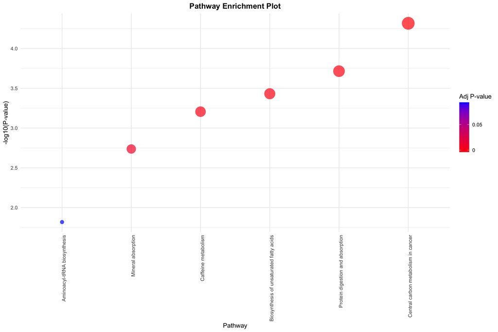

```r
print(results$pathway_plot)
```

The plot displays the enriched pathways along with their corresponding -log10 p-values. Metabolite lists were used as input, and pathway enrichment was performed using Fisher’s exact test based on metabolite-to-pathway mapping.

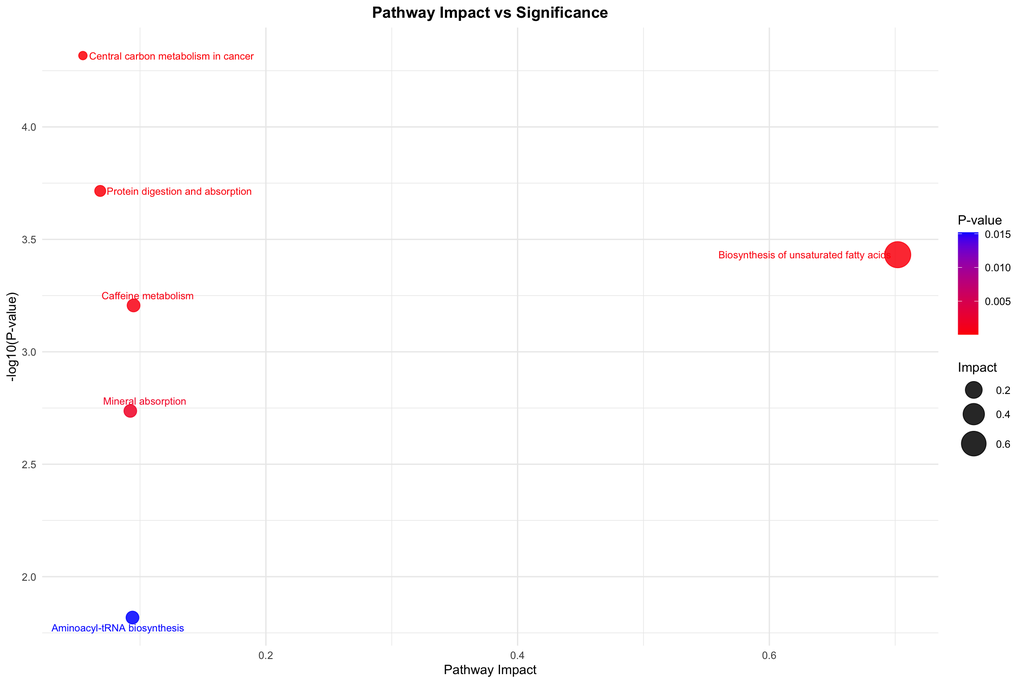

```r
print(results$impact_plot)
```

The plot presents the pathway impact analysis, combining enrichment significance (p-value) with Relative Betweenness Centrality (RBC) to highlight both statistical and topological relevance.

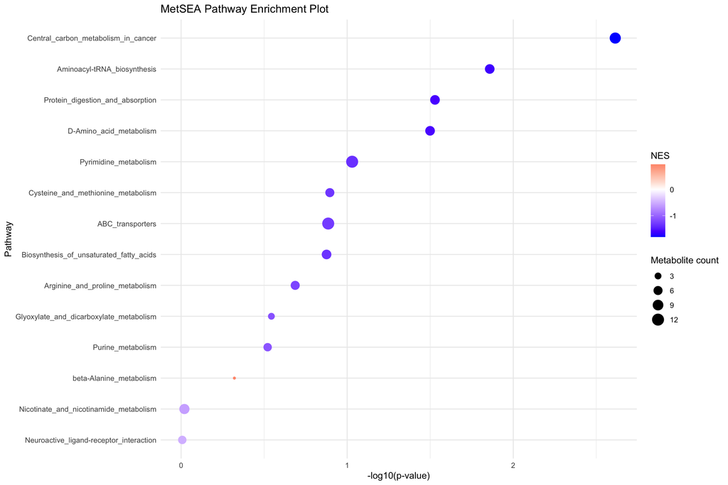

```r
print(results$MetSEA_plot)
```

The plot displays the Metabolite Set Enrichment Analysis (MetSEA) results, highlighting significantly enriched metabolite sets

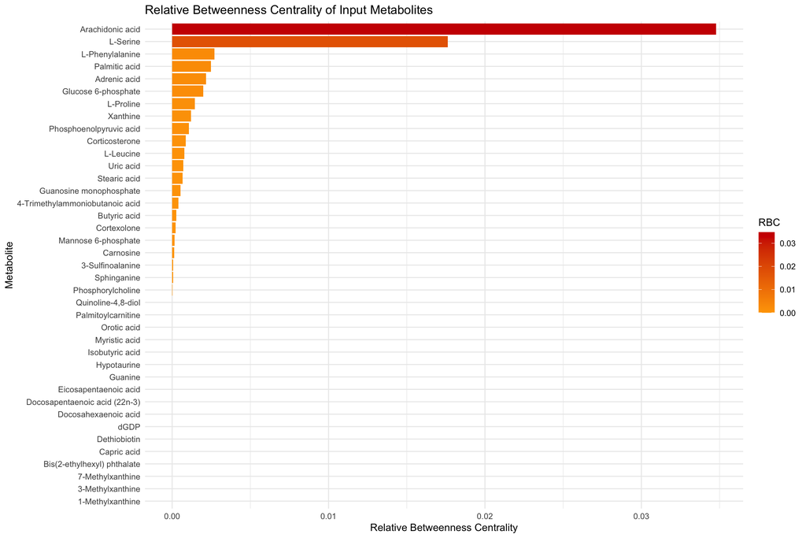

```r
print(results$rbc_plot)
```

The plot illustrates the relative betweenness centrality of the input metabolites, indicating their topological importance and potential regulatory influence within the metabolic network.

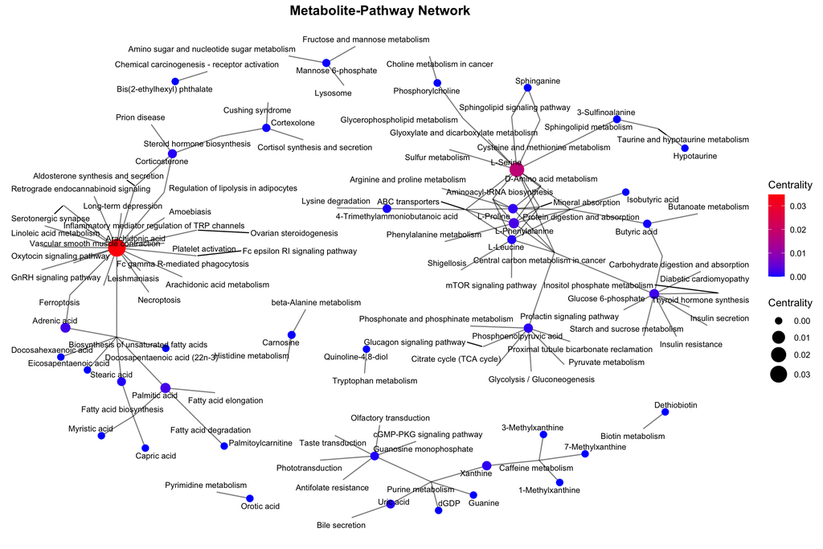

```r
print(results$network_plot)
```

The plot presents the network graph, highlighting the relationships between enriched pathways and input metabolites, and illustrating their connectivity and functional associations within the metabolic network.

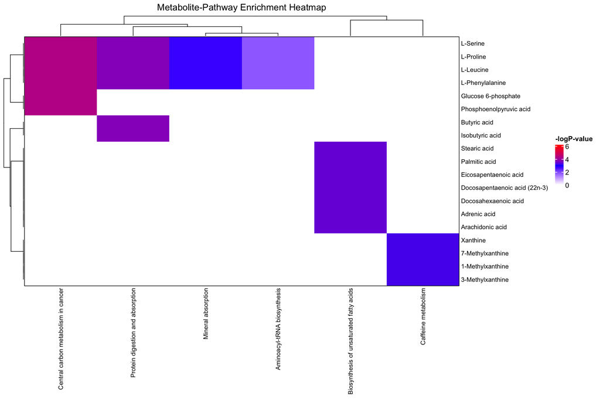

```r
print(results$heatmap_plot)
```

The heatmap displays the gradient of -log p-values, indicating the significance levels of the enriched pathways.

```r
cat('<div style="overflow-x: auto; width: 100%;">')
```

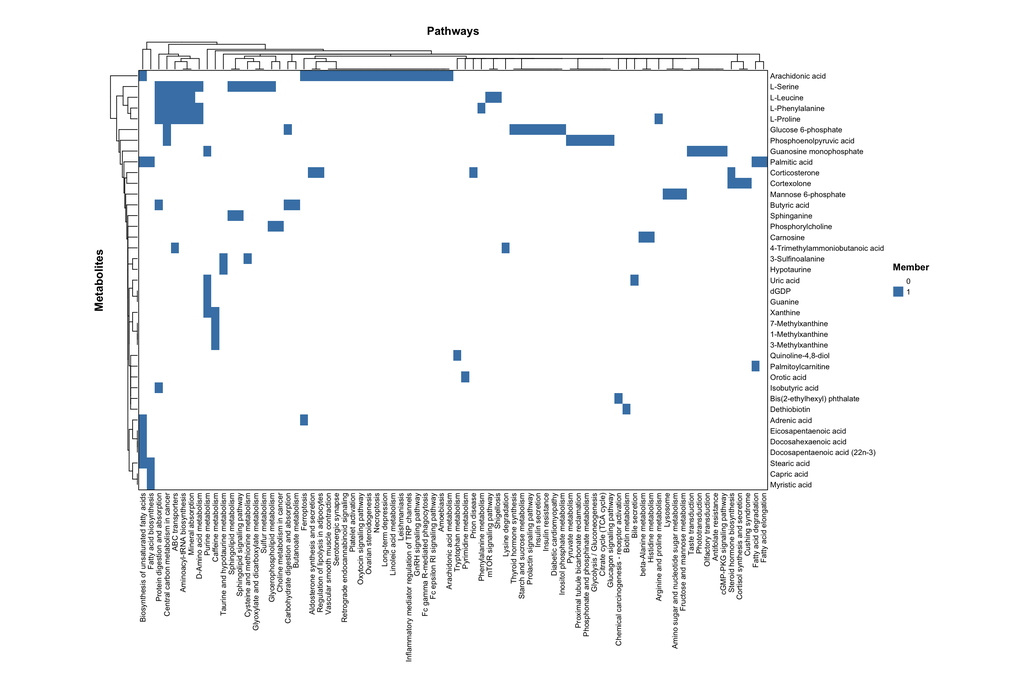

```r
ComplexHeatmap::draw(results$membership_plot)
```

```r
cat('</div>')
```

The plot illustrates pathway membership by showing each pathway along with its associated metabolites.

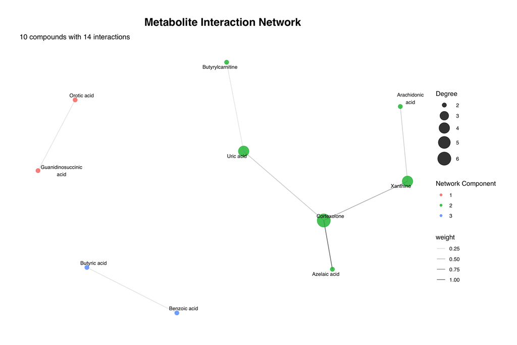

```r
print(results$interaction_plot)
```

The plot displays metabolite interactions derived from chemical-chemical interaction data obtained from STITCH.